# Atividade 1

- **mpg** : Milhas por galão.
- **cylinders** : Número de cilindros entre 4 e 8.
- **displacement** : Deslocamento volumétrico do motor (polegadas cúbicas).
- **horsepower** : Potência do motor.
- **weight** : Peso do veículo (libras).
- **acceleration** : Tempo, em segundos, para acelerar de 0 a 60 mph.
- **year** : Ano do modelo.
- **origin** : Origem do veículo:1. Americano, 2. Europeu, 3. Japonês.
- **name** : Nome do veículo.

As informações em **Auto.csv** são separadas por vírgulas e a primeira linha armazena o nome das variáveis. Use a função **read.csv()**

#### (1) Qual a distribuição de frequências absoluta da variável **origin** do data frame auto?

```r
# Leitura dos dados
# origin: 1 - americano, 2 - europeu e 3 - japonês
auto  <- read.csv("Auto.csv")
table (auto$origin)
```

```
  1   2   3
245  68  79
```

#### (2) Qual a distribuição de frequências relativa da variável **origin** do data frame auto?

1. armazene a distribuição de frequência no objeto **aux**.
2. Utilize a função **sum** para obter o número de carros analizados e armazene esse valor an variável **total**.
3. Armazene em **aux1** a razão entre os valores de **aux** e **total**.
4. Apresente na tela o valor de **aux1**.

```r
aux<-table(auto$origin)
total <- sum(aux)
aux1 <- aux/total
aux1
```

```
        1         2         3
0.6250000 0.1734694 0.2015306
```

#### (3) Elabore um gráfico de barras a partir da tabela de frequencia da origem dos carros?

1. armazene a distribuição de frequência no objeto **aux**.
2. utilize o objeto **aux** para informar a função **barplot** a altura das barras.

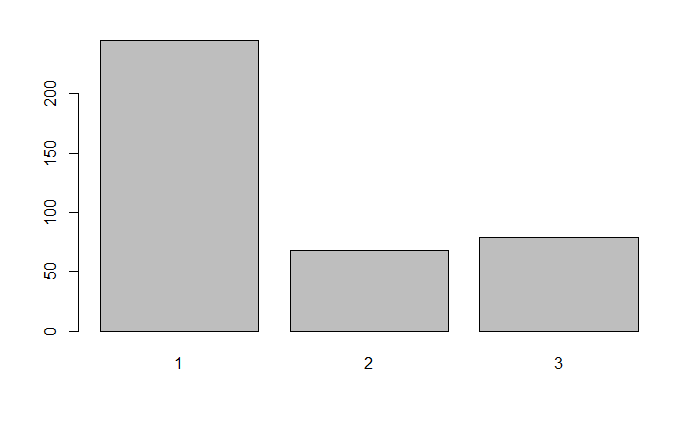

```r
aux <- table(auto$origin)
barplot(aux)
```

#### (4) Elabore um gráfico de barras a partir da tabela de frequência do ano dos carros?

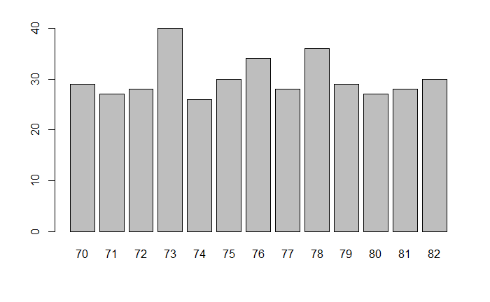

```r
aux <- table(auto$year)
barplot(aux)
```

#### (5) Elabore um gráfico de barras a partir das frequências acumuladas da variável ano?

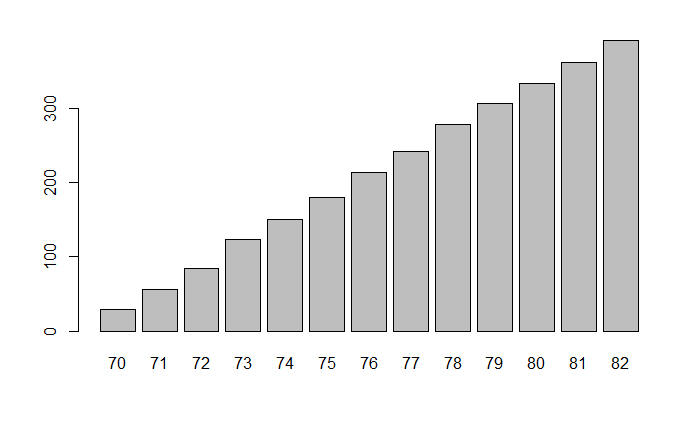

```r
aux <- table(auto$year)
aux1<- cumsum  (aux)
barplot(aux1)
```

```r
aux1
```

```
 70  71  72  73  74  75  76  77  78  79  80  81  82
 29  56  84 124 150 180 214 242 278 307 334 362 392
```

#### (6) Elabore um histograma a partir da variável weight?

1. utilize a função **hist**.
2. número de classes é 20.
3. amplitude da classe 180
4. limite inferior da primeira classe é 1600.
5. limite superior da última classe é 5200.

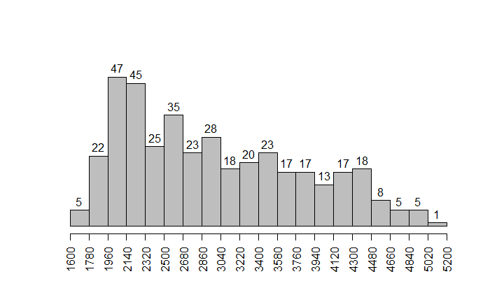

```r
limites <- seq (1600, 5200, by =  180)
aux <-hist(auto$weight, breaks = limites, col="gray", ann= F, axes = F, labels = T, ylim=c(0,60)  )
axis(1, at = limites, las = 2)
```